# Replication

Ishrat Chowdhury

November 13, 2019

# Introduction:

The digestion of starch is initiated by salivary amylase. The amount of salivary amylase can have an effect on starch viscosity. Copy number variations in the AMY1 gene also have an effect on amount of salivary amylase, and thus starch viscosity as well. This paper shows that having high amounts of salivary amylase can cause a viscous starch solution to be broken down faster. In addition, it shows that high AMY1 CNVs lead to more salivary amylase production and therefore faster starch breakdown.

# Results:

Their first set of Figures show the change in starch viscosity over time. Ultimately they found that the impact of saliva either has no effect or causes a rapid decline in starch viscosity. They had two graphs showing the change over time for the 4 subjects with the greatest and least change each. They also had an inset with all the subjects. I did not choose to replicate this because it is just showing change over time, and does not have any statistics. However, the overall change overtime was calculated using this data. We will see how this was done later on.

First let’s load our data, You will need to download the xls file in the following Github repository (https://github.com/ishratc/ishratc-data-replication-assignment/blob/master/pone.0013352.s001.xls) on to your own computer and change the code to match your own file location when stated in the annotations. The reason it was done this way, is because the data they provided was in an xls format, and changing it to a csv corrupted the file. We will be using the package {readxl} to use the data.

```r
library("readxl")
#package helps read excel files

d <- read_excel("C:/Users/Ishrat/Documents/AN 597/pone.0013352.s001.xls", sheet="MVAG")
```

```
## * `` -> ...2
## * `` -> ...3
## * `` -> ...4
## * `` -> ...5
## * `` -> ...6
## * ... and 38 more problems
```

```r
d1 <- read_excel("C:/Users/Ishrat/Documents/AN 597/pone.0013352.s001.xls", sheet="Amylase")
```

```
## * `` -> ...2
## * `` -> ...3
## * `` -> ...4
## * `` -> ...5
## * `` -> ...6
## * ... and 10 more problems
```

```r
#insert your own file directory here
#read_excel is the command used to read the file
#sheet specifies whihc sheet in the file you want to look at we just loaed two sheets

head(d)
```

```
## # A tibble: 6 x 44
##   `Table S1. MVAG~ ...2  ...3   ...4  ...5  ...6  ...7  ...8  ...9 ...10
##   <chr>            <chr> <chr> <dbl> <dbl> <dbl> <dbl> <dbl> <dbl> <dbl>
## 1 Note: Data is n~ <NA>  <NA>     NA    NA    NA    NA    NA    NA    NA
## 2 <NA>             <NA>  Subj~    NA    NA    NA    NA    NA    NA    NA
## 3 <NA>             <NA>  6         8    11    15    21    24    26    27
## 4 Minutes          Seco~ <NA>     NA    NA    NA    NA    NA    NA    NA
## 5 0.0833333333333~ 5     243     252   248   255   218   246   247   249
## 6 <NA>             10    243     251   248   254   218   245   247   248
## # ... with 34 more variables: ...11 <dbl>, ...12 <dbl>, ...13 <dbl>,
## #   ...14 <dbl>, ...15 <dbl>, ...16 <dbl>, ...17 <dbl>, ...18 <dbl>,
## #   ...19 <dbl>, ...20 <dbl>, ...21 <dbl>, ...22 <dbl>, ...23 <dbl>,
## #   ...24 <dbl>, ...25 <dbl>, ...26 <dbl>, ...27 <dbl>, ...28 <dbl>,
## #   ...29 <dbl>, ...30 <dbl>, ...31 <dbl>, ...32 <dbl>, ...33 <dbl>,
## #   ...34 <dbl>, ...35 <dbl>, ...36 <dbl>, ...37 <dbl>, ...38 <dbl>,
## #   ...39 <dbl>, ...40 <dbl>, ...41 <dbl>, ...42 <dbl>, ...43 <dbl>,
## #   ...44 <dbl>
```

```r
head(d1)
```

```
## # A tibble: 6 x 16
##   `Table S2. Amyl~ ...2  ...3  ...4  ...5  ...6  ...7  ...8  ...9  ...10
##   <chr>            <chr> <chr> <chr> <chr> <chr> <chr> <chr> <chr> <chr>
## 1 <NA>             <NA>  <NA>  <NA>  <NA>  <NA>  <NA>  <NA>  <NA>  <NA>
## 2 <NA>             <NA>  <NA>  Amyl~ <NA>  Amyl~ <NA>  AMY1~ <NA>  <NA>
## 3 Subject          Sex   Flow~ Mg/ml Mg/m~ U/ml  U/min Dipl~ SD    Copi~
## 4 1                F     3.41~ 0.88~ 3.03~ 34.1~ 116.~ 5.20~ 0.38~ 5
## 5 2                F     1.70~ 1.10~ 1.89~ 78.7~ 134.~ 5.79  0.89~ 6
## 6 3                M     4.47~ 4.12~ 18.4~ 98.7~ 442.~ 5.87~ 0.32~ 6
## # ... with 6 more variables: ...11 <lgl>, ...12 <lgl>, ...13 <lgl>,
## #   ...14 <chr>, ...15 <chr>, ...16 <chr>
```

We can see that our data is loaded but there are a lot of NA’s and the headers don’t make a lot of sense. We also get a list of problems. This is fine because we will be formatting this data as we go.

The first kind of data analysis they do is reporting mean and standard deviations of amylase amount, amylase concentration per minute, amylase activity per unit, and amylase activity per minute. The process of this is below.

As mentioned before, first we need to clean up the data.

```r
d1 <- d1[-c(1:3),]
#gets rid of the first 3 rows

names(d1) <- c("subject", "sex", "flowrate", "mg/ml", "mg/min", "U/ml", "U/min", "Diploid_AMY1_copies", "SD", "Copies")
#renames the row
```

```r
#Amylase Amount mg/ml

mg_ml<-d1[1:65, "mg/ml"]
ex_mg_ml<-d1[69:73, "mg/ml"] #add external subject data
mg_ml<-as.numeric(unlist(mg_ml)) #make it a list of numbers
ex_mg_ml<-as.numeric(unlist(ex_mg_ml)) #repeat for external subjects
mg_ml<-c(ex_mg_ml, mg_ml) #combine the external subjects with the original subjects
mean_mg_ml<-mean(mg_ml)
mean_mg_ml # mean amylase mg/ml 2.63 mg/ml (Mandel, 2.64 mg/ml)
```

```
## [1] 2.633382
```

```r
sd_mg_ml<- sd(mg_ml)
sd_mg_ml #sd amylase mg/ml 1.85 mg/ml (Mandel, 1.8 mg/ml)
```

```
## [1] 1.846597
```

This matches the paper! The difference might be because they may have rounded differently or decided to leave a subject out. The n for these numbers was not stated in the paper. Let’s do it for the rest of the values.

```r
#Amylase Amount mg/min

mg_min<-d1[1:65, "mg/min"]
ex_mg_min<-d1[69:73, "mg/min"]
mg_min<-as.numeric(unlist(mg_min))
ex_mg_min<-as.numeric(unlist(ex_mg_min))
mg_min<-c(ex_mg_min, mg_min)
mean_mg_min<-mean(mg_min)
mean_mg_min # mean amylase mg/min 5.64 mg/min (Mandel, 5.7 mg/min)
```

```
## [1] 5.645645
```

```r
sd_mg_min<- sd(mg_min)
sd_mg_min #sd amylase mg/min 7.25 mg/min (Mandel, 7.1 mg/min)
```

```
## [1] 7.259757
```

```r
#Amylase Activity U/ml

U_ml<-d1[1:65, "U/ml"]
ex_U_ml<-d1[69:73, "U/ml"]
U_ml<-as.numeric(unlist(U_ml))
ex_U_ml<-as.numeric(unlist(ex_U_ml))
U_ml<-c(ex_U_ml, U_ml)
mean_U_ml<-mean(U_ml)
mean_U_ml # mean amylase U/ml 93.09 U/ml (Mandel, 93U/ml )
```

```
## [1] 93.09368
```

```r
sd_U_ml<- sd(U_ml)
sd_U_ml #sd amylase U/ml 62.63 U/ml (Mandel, 62 U/ml)
```

```
## [1] 62.63331
```

```r
#Amylase Activity U/min

U_min<-d1[1:65, "U/min"]
ex_U_min<-d1[69:73, "U/min"]
U_min<-as.numeric(unlist(U_min))
ex_U_min<-as.numeric(unlist(ex_U_min))
U_min<-c(ex_U_min, U_min)
mean_U_min<-mean(U_min)
mean_U_min # mean amylase U/min 176.88 U/min (Mandel, 177 U/min)
```

```
## [1] 176.8762
```

```r
sd_U_min<- sd(U_min)
sd_U_min #sd amylase U/min 166.16 U/min (Mandel, 166 U/min)
```

```
## [1] 166.1626
```

The next set of analysis they did was correlating amylase measures with each other. They looked at the relationship between amyl amount (mg/ml) and overall viscosity change. For us to look at this first we need to get the overall viscosity change.

```r
#First clean-up the data
MVAG<-d #add raw data
MVAG<-MVAG[-c(90:276),] # take out rows of NA
MVAG<-MVAG[-c(1:27),] #they only used data from 120-425 seconds, take out rows for 0-120 seconds
MVAG<-MVAG[-c(1:2)] #take out the minutes and seconds columns
colnames(MVAG)<-as.numeric(1:42) #rename the columns as numbers
str(MVAG) #check what we made
```

```
## Classes 'tbl_df', 'tbl' and 'data.frame':    62 obs. of  42 variables:
##  $ 1 : chr  "235" "234" "234" "233" ...
##  $ 2 : num  235 234 233 231 229 227 224 221 219 215 ...
##  $ 3 : num  235 234 234 232 230 229 225 224 224 223 ...
##  $ 4 : num  235 235 233 233 232 231 228 227 226 225 ...
##  $ 5 : num  235 236 237 232 232 230 229 228 224 224 ...
##  $ 6 : num  235 235 233 233 228 222 221 219 217 214 ...
##  $ 7 : num  235 235 234 233 230 228 226 226 224 223 ...
##  $ 8 : num  235 235 234 234 234 232 209 202 182 164 ...
##  $ 9 : num  235 235 234 232 231 230 227 226 225 223 ...
##  $ 10: num  235 235 234 233 232 231 230 229 228 227 ...
##  $ 11: num  235 234 234 234 233 231 232 226 225 221 ...
##  $ 12: num  235 235 233 229 226 223 221 219 216 213 ...
##  $ 13: num  235 235 235 235 234 231 229 228 227 224 ...
##  $ 14: num  235 235 229 225 222 219 215 213 212 210 ...
```

[output cut: 28 more lines]

```r
#for some reason column 1 is in character we want it to be numeric
MVAG$`1`<-as.numeric(as.character(MVAG$`1`))
str(MVAG)
```

```
## Classes 'tbl_df', 'tbl' and 'data.frame':    62 obs. of  42 variables:
##  $ 1 : num  235 234 234 233 231 227 226 224 222 222 ...
##  $ 2 : num  235 234 233 231 229 227 224 221 219 215 ...
##  $ 3 : num  235 234 234 232 230 229 225 224 224 223 ...
##  $ 4 : num  235 235 233 233 232 231 228 227 226 225 ...
##  $ 5 : num  235 236 237 232 232 230 229 228 224 224 ...
##  $ 6 : num  235 235 233 233 228 222 221 219 217 214 ...
##  $ 7 : num  235 235 234 233 230 228 226 226 224 223 ...
##  $ 8 : num  235 235 234 234 234 232 209 202 182 164 ...
##  $ 9 : num  235 235 234 232 231 230 227 226 225 223 ...
##  $ 10: num  235 235 234 233 232 231 230 229 228 227 ...
##  $ 11: num  235 234 234 234 233 231 232 226 225 221 ...
##  $ 12: num  235 235 233 229 226 223 221 219 216 213 ...
##  $ 13: num  235 235 235 235 234 231 229 228 227 224 ...
##  $ 14: num  235 235 229 225 222 219 215 213 212 210 ...
```

[output cut: 28 more lines]

```r
#check again
#everyhting is numeric

MVAG<-as.matrix(MVAG) #turn it into a matrix so we can do some calculations

max_MVAG<-apply(MVAG, 2, max)
max_MVAG<-as.numeric(unlist(max_MVAG))
max_MVAG #vector of all max values
```

```
##  [1] 235 235 235 235 237 235 235 235 235 235 235 235 235 235 235 236 235
## [18] 235 235 235 235 235 247 235 235 235 236 235 235 237 235 235 235 236
## [35] 235 235 235 235 235 235 235 235
```

```r
min_MVAG<-apply(MVAG, 2, min)
min_MVAG<-as.numeric(unlist(min_MVAG))
min_MVAG #vector of all min values
```

```
##  [1] 192 168 196 204 200 171 190  46 197 210 126 166 183 184 228 219 223
## [18] 216 209 202 192 234 235 202 221 231 205 163 232 232 193 197 195 222
## [35] 173 208 197 202 218 202 161 136
```

```r
MVAG_change<-(max_MVAG-min_MVAG)
MVAG_change
```

```
##  [1]  43  67  39  31  37  64  45 189  38  25 109  69  52  51   7  17  12
## [18]  19  26  33  43   1  12  33  14   4  31  72   3   5  42  38  40  14
## [35]  62  27  38  33  17  33  74  99
```

```r
#vector of overall change in viscocity
#these are the y values for the first 2 panels of Figure 2
```

Now that we have the y values let’s focus on the x values. In panel a of Figure 2 they compare overall viscosity to amylase amount (mg/ml). We have to keep in mind that they did not use the external subjects for this, and the data for overall viscosity is only available for a certain group of subjects. Let’s start by getting a vector of the subjects

```r
subjects<- d[-c(1:2),]
subjects<-subjects["1",(3:44)] #this string contains the subjects they used for MVAG
subjects<-as.numeric(unlist(subjects))
subjects
```

```
##  [1]  6  8 11 15 21 24 26 27 28 31 32 33 34 35 36 37 38 39 40 41 42 43 44
## [24] 45 46 47 48 49 50 51 52 53 54 55 56 57 58 59 60 61 62 65
```

We can use this to get the right number for amylase amount.

```r
MVAG_mg_ml<-d1[1:65, "mg/ml"] #add the mg/ml data
MVAG_mg_ml<-MVAG_mg_ml[subjects,] #make it correspond to the right subjects
str(MVAG_mg_ml)
```

```
## Classes 'tbl_df', 'tbl' and 'data.frame':    42 obs. of  1 variable:
##  $ mg/ml: chr  "2.7723090000000004" "3.6993428000000002" "5.6920680000000008" "2.124838" ...
```

```r
MVAG_mg_ml$`mg/ml`<-as.numeric(as.character(MVAG_mg_ml$`mg/ml`)) #make them numeric
MVAG_mg_ml<-unlist(MVAG_mg_ml$"mg/ml")
MVAG_mg_ml #now we have vector of x values for panel a in Figure 2
```

```
##  [1] 2.772309 3.699343 5.692068 2.124838 3.275371 5.000009 4.112238
##  [8] 6.701332 1.296409 2.711988 2.851905 2.792838 3.317638 3.836868
## [15] 0.000000 3.996509 2.917268 1.616068 4.551505 1.331709 4.123709
## [22] 0.000000 0.288809 2.445009 0.294109 0.861109 2.110909 2.578709
## [29] 0.081509 0.000000 2.848909 3.925709 3.889809 2.694509 5.450109
## [36] 1.660509 4.970109 2.831909 1.625509 3.890509 0.720909 6.720305
```

It looks like we have 42 values but the paper mentions 41. I remove one outlier point, although the specific point they removed is not mentioned in the paper. I find the r value and p value and plot the results next. Pretty close! Differences might be due to rounding, or how they cleaned up the data with outliers.

```r
MVAG_change<-MVAG_change[-c(8)]
MVAG_mg_ml<-MVAG_mg_ml[-c(8)]

figure_2a<-lm(MVAG_change ~ MVAG_mg_ml)
figure_2a_r<-sqrt(summary(figure_2a)$r.squared)
figure_2a_r<-signif(figure_2a_r, digits=2)
figure_2a_r #Figure 2a r value = 0.56 (Mandel 0.58)
```

```
## [1] 0.56
```

```r
figure_2a_p<-summary(figure_2a)$coefficients[2,4]
figure_2a_p #p value 0.00016 (Mandel reports that it is less than 0.0001, in this case it isn't but it is still significant, could eb a rounding error)
```

```
## [1] 0.0001604882
```

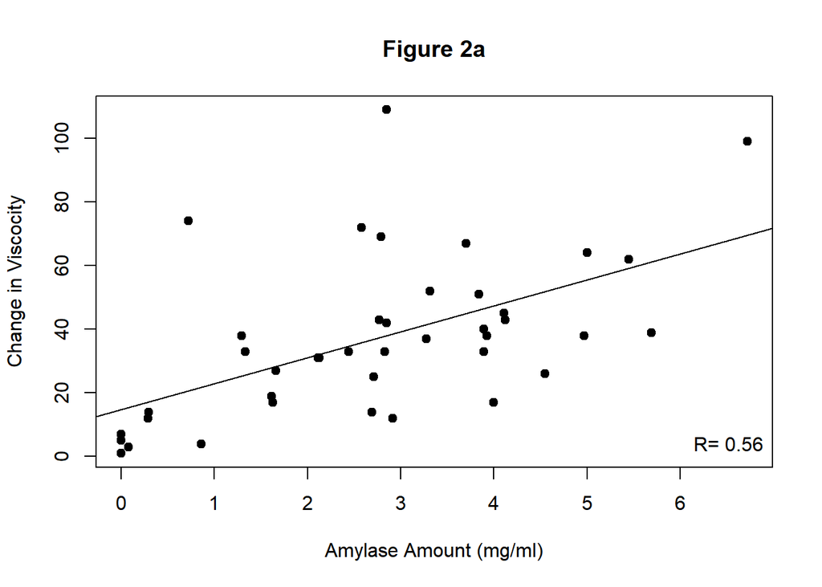

```r
plot(x=MVAG_mg_ml, y=MVAG_change, main="Figure 2a", xlab= "Amylase Amount (mg/ml)", ylab = "Change in Viscocity", pch =19)
abline(lm (MVAG_change ~ MVAG_mg_ml))
legend ("bottomright", bty = "n", legend=paste("R=", figure_2a_r))
```

```r
MVAG_U_ml<-d1[1:65, "U/ml"]
MVAG_U_ml<-MVAG_U_ml[subjects,]
str(MVAG_U_ml)
```

```
## Classes 'tbl_df', 'tbl' and 'data.frame':    42 obs. of  1 variable:
##  $ U/ml: chr  "88.122666666666646" "131" "142.57066666666668" "75.221333333333334" ...
```

```r
MVAG_U_ml$`U/ml`<-as.numeric(as.character(MVAG_U_ml$`U/ml`))
MVAG_U_ml<-unlist(MVAG_U_ml$"U/ml")
MVAG_U_ml #x values for figure 2b
```

```
##  [1]  88.122667 131.000000 142.570667  75.221333  84.405333 216.000000
##  [7] 125.514667 350.522667  86.810667 129.450667  97.306667 104.741333
## [13]  81.562667  75.221333   4.373333  74.565333  52.261333  26.458667
## [19] 122.234667  64.506667 111.957333   1.312000  33.674667 103.648000
## [25]  40.672000  51.605333 103.429333 127.000000  14.213333   4.373333
## [31] 104.085333 103.429333 131.200000  50.512000 132.293333  66.474667
## [37]  98.837333  95.120000  45.920000  79.157333  39.360000 179.744000
```

```r
MVAG_U_ml<-MVAG_U_ml[-c(8)] #remove outlier

figure_2b<-lm(MVAG_change ~ MVAG_U_ml)
figure_2b_r<-sqrt(summary(figure_2b)$r.squared)
figure_2b_r<-signif(figure_2b_r, digits=2)
figure_2b_r #Figure 2b r value = 0.66 (Mandel 0.67)
```

```
## [1] 0.66
```

```r
figure_2b_p<-summary(figure_2b)$coefficients[2,4]
figure_2b_p #p value is less than 0.0001
```

```
## [1] 2.815889e-06
```

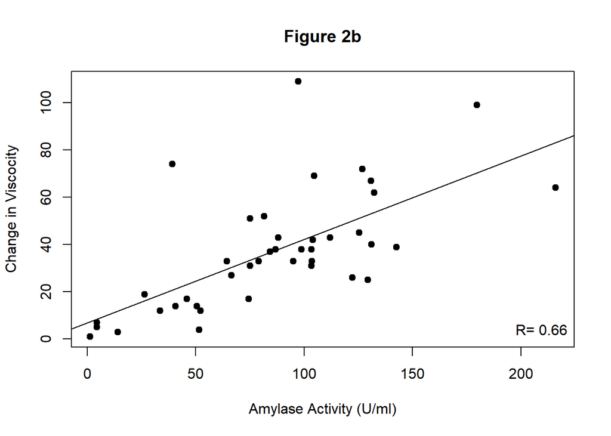

```r
plot(x=MVAG_U_ml, y=MVAG_change, main="Figure 2b", xlab= "Amylase Activity (U/ml)", ylab = "Change in Viscocity", pch=19 )
abline(lm (MVAG_change ~ MVAG_U_ml))
legend ("bottomright", bty = "n", legend=paste("R=", figure_2b_r))
```

```r
figure_2c<-lm(U_ml ~ mg_ml)
figure_2c_r<-sqrt(summary(figure_2c)$r.squared)
figure_2c_r<-signif(figure_2c_r, digits=2)
figure_2c_r #Figure 2c r value = 0.61 (Mandel 0.61)
```

```
## [1] 0.61
```

```r
figure_2c_p<-summary(figure_2c)$coefficients[2,4]
figure_2c_p #p value is less than 0.0001
```

```
## [1] 2.364828e-08
```

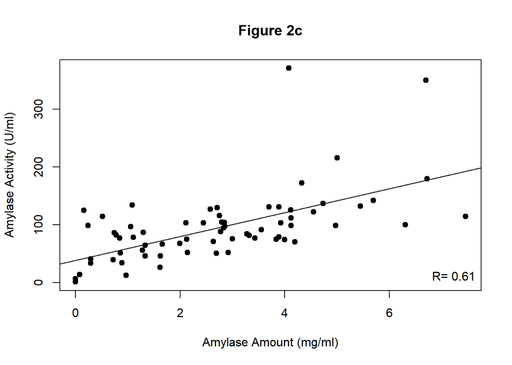

```r
plot(x=mg_ml, y=U_ml, main="Figure 2c", xlab= "Amylase Amount (mg/ml)", ylab = "Amylase Activity (U/ml)", pch=19 )
abline(lm (U_ml ~ mg_ml))
legend ("bottomright", bty = "n", legend=paste("R=", figure_2c_r))
```

We have completed analysis on salivary amylase measures and showed that amount, activity, and viscosity are correlated.

Now let’s move on to AMY1 copy number analysis. We start by finding the mean and standard deviation.

```r
AMY1_copies<-d1[1:64, "Diploid_AMY1_copies"]
AMY1_copies<-as.numeric(unlist(AMY1_copies))
AMY1_copies<-AMY1_copies[-c(29,41)] #remove NA
AMY1_copies
```

```
##  [1]  5.20  5.79  5.87 10.98  5.83  6.19  6.12  3.94  3.48  1.38  4.60
## [12]  4.19  4.84  3.49  3.03  2.80  4.46  4.54  6.86  3.96  4.98  3.18
## [23]  2.72  5.95  4.21  8.36 10.63  2.47  2.42  4.34  1.94  3.67  3.81
## [34]  6.40  1.11  3.73  3.32  2.22  3.65  4.89  6.64  4.30  3.42  3.05
## [45]  1.78  3.02  4.89  2.19  2.14  7.03  4.52  3.27  2.20  5.12  5.10
## [56]  3.17  4.04  5.72  4.60  5.23  5.67  5.53
```

```r
AMY1_copies_mean<-mean(AMY1_copies)
AMY1_copies_mean # mean copies 4.4 (Mandel, 4.4)
```

```
## [1] 4.422258
```

```r
sd_AMY1_copies<- sd(AMY1_copies)
sd_AMY1_copies #sd copies 1.9 (Mandel, 2)
```

```
## [1] 1.917235
```

Next we correlate copy number to amylase amount. We need to make sure we are using data from the same subjects we have data for copy numbers. Then we plot it.

```r
AMY_mg_ml<-d1[1:64, "mg/ml"] #add the mg/ml data
AMY_mg_ml<-as.numeric(unlist(AMY_mg_ml))
AMY_mg_ml<-AMY_mg_ml[-c(29,41)]
AMY_mg_ml
```

```
##  [1] 0.8894707 1.1068790 4.1225168 6.3054246 0.7437580 2.7723090 4.3276909
##  [8] 3.6993428 0.7795632 0.0000000 5.6920680 1.0541580 2.7510795 0.8469518
## [15] 2.1248380 0.2432626 0.5184326 0.1606314 4.0773905 1.0840151 3.2753713
## [22] 1.2806480 3.4273080 5.0000090 4.1909082 4.1122380 6.7013323 1.2964090
## [29] 0.9659780 2.7119880 2.8519047 2.7928380 3.3176380 3.8368680 0.0000000
## [36] 3.9965090 2.9172680 1.6160680 4.5515047 4.1237090 0.0000000 0.2888090
## [43] 2.4450090 0.2941090 0.8611090 2.1109090 2.5787090 0.0815090 0.0000000
## [50] 2.8489090 3.9257090 3.8898090 2.6945090 5.4501090 1.6605090 4.9701090
## [57] 2.8319090 1.6255090 3.8905090 0.7209090 1.3311090 7.4552090
```

```r
figure_3<-lm(AMY_mg_ml ~ AMY1_copies)
figure_3_r<-sqrt(summary(figure_3)$r.squared)
figure_3_r<-signif(figure_3_r, digits=2)
figure_3_r #Figure 2c r value = 0.50 (Mandel 0.50)
```

```
## [1] 0.5
```

```r
figure_3_p<-summary(figure_3)$coefficients[2,4]
figure_3_p #p value is less than 0.0001
```

```
## [1] 3.774045e-05
```

```r
AMY1_copies_round<-trunc(AMY1_copies) #round copy numbers
AMY1_copies_round
```

```
##  [1]  5  5  5 10  5  6  6  3  3  1  4  4  4  3  3  2  4  4  6  3  4  3  2
## [24]  5  4  8 10  2  2  4  1  3  3  6  1  3  3  2  3  4  6  4  3  3  1  3
## [47]  4  2  2  7  4  3  2  5  5  3  4  5  4  5  5  5
```

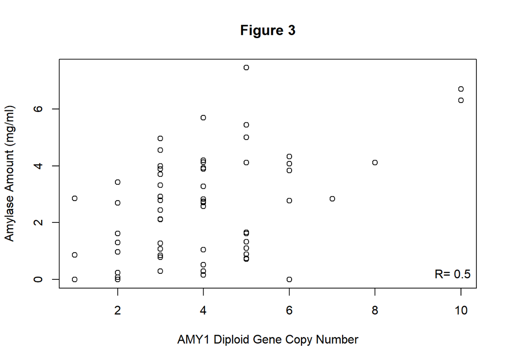

[figure not shown]

```r
plot(x=AMY1_copies_round, y=AMY_mg_ml, main="Figure 3", xlab= "AMY1 Diploid Gene Copy Number", ylab = "Amylase Amount (mg/ml)" )
legend ("bottomright", bty = "n", legend=paste("R=", figure_3_r))
```

Figure, r value and p value recreated.

The next thing they did was plot the change of viscosity perception over time based on different stimuli. I again did not replicate this one because it just showed change over time. They found that there were large individual differences in perception. Finally they subsetted some of this data to make Figure 5. Subjects were divided based on their amylase levels then this was related to their overall viscosity perception and half of their viscosity perception. Since this involves introducing a new sheet in the original dataset, and subsetting the exisitng data multiple times, this was not recreated either. They found that amylase levels were related to precieved viscocity.

# Conclusion:

Overall this papaer showed that amylase amount, activity, and viscosity are related. We were able to find descriptive statistics on this as well as create figures and inferential statistics. We also showed that amylase amount was correlated with copy number variations in the AMY1 gene.